# Bài 6 — Phân tích Sống còn (tùy chọn / nâng cao)

Phân tích Dữ liệu Lâm sàng bằng R (Giai đoạn I) — Trước khóa học

Neudata

> **Bài học này là tùy chọn.** Nó giới thiệu trước phần phân tích “thời gian đến biến cố” (time-to-event) mà chúng ta sẽ học sâu hơn ở phần sau của khóa học. Hãy đọc lướt nếu bạn tò mò; bạn **không** cần phải thành thạo nó trước ngày học đầu tiên.

## Mục tiêu của bài học này

Đôi khi biến kết cục không chỉ là *liệu* một biến cố có xảy ra hay không, mà là *khi nào* nó xảy ra. **Phân tích sống còn** xử lý điều này, bao gồm cả các bệnh nhân được theo dõi trong những khoảng thời gian khác nhau (**kiểm duyệt**). Bạn sẽ làm quen với **đường cong Kaplan–Meier**, **kiểm định log-rank**, và **hồi quy Cox**.

Biến kết cục của chúng ta dùng hai biến cùng nhau:

- `time_to_event` — số tháng theo dõi, và
- `outcome` — 1 nếu biến cố (biến cố tim mạch hoặc tử vong) đã xảy ra, 0 nếu bệnh nhân không có biến cố vào thời điểm kết thúc (bị kiểm duyệt).

```r
library(tidyverse)
library(survival)    # các công cụ sống còn cốt lõi
library(survminer)   # biểu đồ sống còn đẹp

clinical_data <- read_csv("../Data/clinical_data_clean.csv")

# Đặt "Untreated" đứng trước để tỷ số nguy cơ mô tả tác động của việc được Điều trị
clinical_data <- clinical_data %>%
  mutate(treatment = factor(treatment, levels = c("Untreated", "Treated")))
```

## 1. Đối tượng sống còn (survival object)

`Surv()` gói thời gian và biến cố lại với nhau.

```r
# Surv(time, event): thời gian được theo dõi, và liệu biến cố có xảy ra hay không
surv_obj <- Surv(clinical_data$time_to_event, clinical_data$outcome)
head(surv_obj)   # dấu "+" nghĩa là bị kiểm duyệt (chưa có biến cố)
```

```
## [1] 24.0+ 24.0+ 24.0+  3.8  24.0+ 24.0+
```

## 2. Đường cong Kaplan–Meier

**Câu hỏi:** Liệu bệnh nhân **được điều trị** có duy trì không có biến cố lâu hơn bệnh nhân **không được điều trị** không?

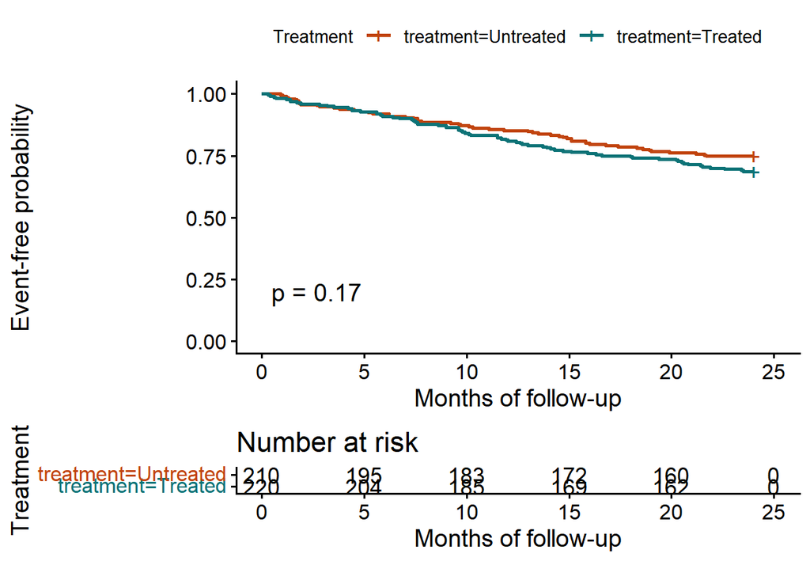

```r
# Ước lượng sống còn riêng theo từng nhóm điều trị
km_fit <- survfit(Surv(time_to_event, outcome) ~ treatment, data = clinical_data)

ggsurvplot(km_fit, data = clinical_data,
           pval = TRUE, risk.table = TRUE,
           legend.title = "Treatment",
           xlab = "Months of follow-up", ylab = "Event-free probability",
           palette = c("#C1440E", "#0D7377"))
```

## 3. Kiểm định log-rank

```r
survdiff(Surv(time_to_event, outcome) ~ treatment, data = clinical_data)
```

```
## Call:
## survdiff(formula = Surv(time_to_event, outcome) ~ treatment,
##     data = clinical_data)
##
##                       N Observed Expected (O-E)^2/E (O-E)^2/V
## treatment=Untreated 210       53     60.5     0.935      1.86
## treatment=Treated   220       69     61.5     0.921      1.86
##
##  Chisq= 1.9  on 1 degrees of freedom, p= 0.2
```

**Diễn giải:** một giá trị p nhỏ nghĩa là trải nghiệm sống còn thực sự khác nhau giữa bệnh nhân được điều trị và không được điều trị.

## 4. Hồi quy Cox — tỷ số nguy cơ

**Mô hình Cox** cho ra một **tỷ số nguy cơ (HR)** và, giống như hồi quy logistic, cho phép chúng ta **hiệu chỉnh** cho các biến khác.

```r
# Mô hình thô: chỉ có treatment
cox_crude <- coxph(Surv(time_to_event, outcome) ~ treatment, data = clinical_data)
summary(cox_crude)
```

```
## Call:
## coxph(formula = Surv(time_to_event, outcome) ~ treatment, data = clinical_data)
##
##   n= 430, number of events= 122
##
##                    coef exp(coef) se(coef)     z Pr(>|z|)
## treatmentTreated 0.2483    1.2819   0.1827 1.359    0.174
##
##                  exp(coef) exp(-coef) lower .95 upper .95
## treatmentTreated     1.282     0.7801    0.8961     1.834
##
## Concordance= 0.53  (se = 0.023 )
## Likelihood ratio test= 1.86  on 1 df,   p=0.2
## Wald test            = 1.85  on 1 df,   p=0.2
## Score (logrank) test = 1.86  on 1 df,   p=0.2
```

```r
# Mô hình đã hiệu chỉnh: tính đến tuổi và bệnh đồng mắc
cox_adj <- coxph(Surv(time_to_event, outcome) ~ age + diabetes + hypertension + treatment,
                 data = clinical_data)

library(broom)
tidy(cox_adj, exponentiate = TRUE, conf.int = TRUE)
```

```
## # A tibble: 4 × 7
##   term             estimate std.error statistic      p.value conf.low conf.high
##   <chr>               <dbl>     <dbl>     <dbl>        <dbl>    <dbl>     <dbl>
## 1 age                 1.05    0.00864      5.52 0.0000000340    1.03      1.07
## 2 diabetesYes         2.21    0.209        3.78 0.000155        1.46      3.33
## 3 hypertensionYes     1.65    0.223        2.24 0.0250          1.07      2.56
## 4 treatmentTreated    0.550   0.220       -2.72 0.00660         0.357     0.847
```

**Kết quả → Diễn giải (tỷ số nguy cơ):**

- `treatment (Treated)`: HR ≈ **0.55** — bệnh nhân được điều trị có nguy cơ xảy ra biến cố tại bất kỳ thời điểm nào **thấp hơn khoảng 45%**, sau khi hiệu chỉnh.
- `age`: HR ≈ 1.05 mỗi năm; `diabetes`: HR ≈ 2.2; `hypertension`: HR ≈ 1.6 — tất cả đều làm tăng nguy cơ.

Một HR **dưới 1** nghĩa là nguy cơ thấp hơn (bảo vệ); **trên 1** nghĩa là nguy cơ cao hơn.

**Báo cáo:** *“Sau khi hiệu chỉnh cho tuổi, đái tháo đường và tăng huyết áp, việc điều trị có liên quan đến nguy cơ (hazard) thấp hơn đối với biến cố tổng hợp (HR 0.55, KTC 95% 0.36–0.85).”*

## Những điểm chính cần ghi nhớ

- Dữ liệu sống còn = **thời gian** + **chỉ báo biến cố**; `Surv(time, event)` kết hợp chúng.
- Đường cong **Kaplan–Meier** cho thấy xác suất không có biến cố theo thời gian; kiểm định **log-rank** so sánh các nhóm.
- **Hồi quy Cox** cho các **tỷ số nguy cơ** đã hiệu chỉnh; HR < 1 là bảo vệ.
- Kiểm duyệt (theo dõi không hoàn chỉnh) được xử lý tự động — một ưu điểm then chốt.

## Tự thực hành (tùy chọn)

1. Vẽ các đường cong Kaplan–Meier của `outcome`/`time_to_event` theo `diabetes`.
2. Chạy một kiểm định log-rank cho so sánh theo diabetes.
3. Khớp một mô hình Cox chỉ với `age + treatment` và báo cáo HR của treatment.